# Pb and Parks

Marc Los Huertos

11/25/2019

## Introduction

As we have learned, R can be powerful, but it’s often hard to remember what to do if it’s been a while since you have used it. I have created this document to help you analyze the Pb data – why? Because I am more interested in having you understand what the analysis process is than the actual R code.

But some understanding of R is useful so you can see the steps needed for the analysis!

## Read the Data

First, we read the data. I like to create a filename object that I can modify based on my own path and filename.

```r
filename = "/home/CAMPUS/mwl04747/github/beginnersluck/Pb_and_Parks/EA 30 Data Entry - Sheet1.csv"
import <- read.csv(filename)
str(import)
```

```
## 'data.frame':    67 obs. of  37 variables:
##  $ Type              : Factor w/ 3 levels "CalBlk","CalStd",..: 1 2 2 2 3 3 3 3 3 3 ...
##  $ Level             : int  NA 1 2 3 NA NA NA NA NA NA ...
##  $ Sample.Name       : Factor w/ 54 levels "1","10","11",..: 50 50 52 54 50 1 12 23 34 45 ...
##  $ Rack              : Factor w/ 2 levels "Monday","Tuesday": NA NA NA NA NA 1 1 1 1 1 ...
##  $ Cap....marc.s.IDs.: int  NA NA NA NA NA 1 2 3 4 5 ...
##  $ EA30_IDs          : Factor w/ 49 levels "#13 Sample 1 CPark",..: NA NA NA NA NA 8 11 12 13 17 ...
##  $ PARK              : Factor w/ 11 levels "","Blaisdell",..: NA NA NA NA NA 7 7 2 2 2 ...
##  $ Partner.Names     : Factor w/ 4 levels "","Pauline and Lucy",..: 1 1 1 1 1 1 1 2 4 2 ...
##  $ Replicate         : int  NA NA NA NA NA NA NA NA NA NA ...
##  $ DISTANCE10        : Factor w/ 9 levels "1,392.00","1,768.00",..: NA NA NA NA NA 2 2 9 9 9 ...
##  $ DISTANCE66        : num  NA NA NA NA NA ...
##  $ Vial.Number       : int  1101 1101 1301 1201 1101 3101 3102 3103 3104 3105 ...
##  $ Na23              : Factor w/ 64 levels "","<0.000","0",..: 2 3 60 48 6 58 27 59 9 10 ...
##  $ Mg24              : num  3.57e-04 0.00 6.65e+01 4.98e+02 1.62e-02 ...
```

[output cut: 23 more lines]

I fixed some of the values that were treated as factors, i.e. categorical data. For example, Pb has “<0.0001” which was treated as a character string instead of a numeric value – this the entire variable was being treated as a character string. We fixed that by changing “<0.0001” to 0. I haven’t done this for other variables yet.

## Exploratory Analysis

We can easily make a histogram as below…

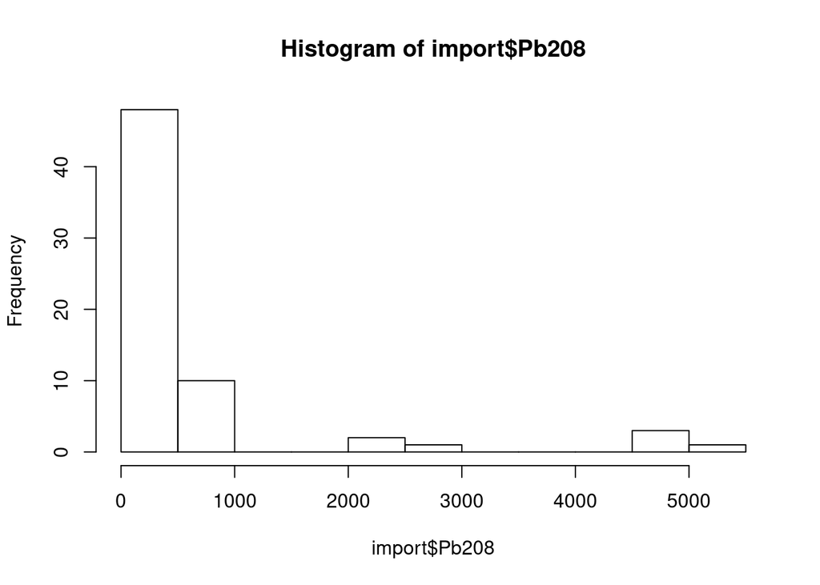

```r
hist(import$Pb208)
```

However, we only want to use the sample data, not the standards and blanks to calibrate the analysis run. See the Column A in the google sheet. So, let’s subset the data to use only the sample data.

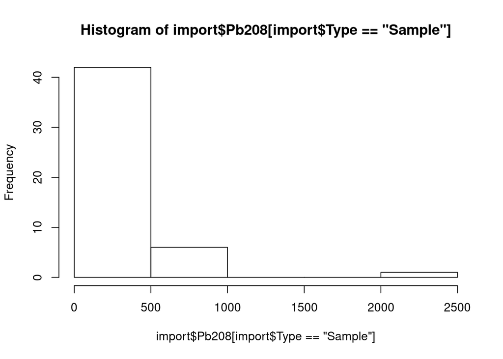

```r
hist(import$Pb208[import$Type=="Sample"])
```

Let’s clean this up a bit:

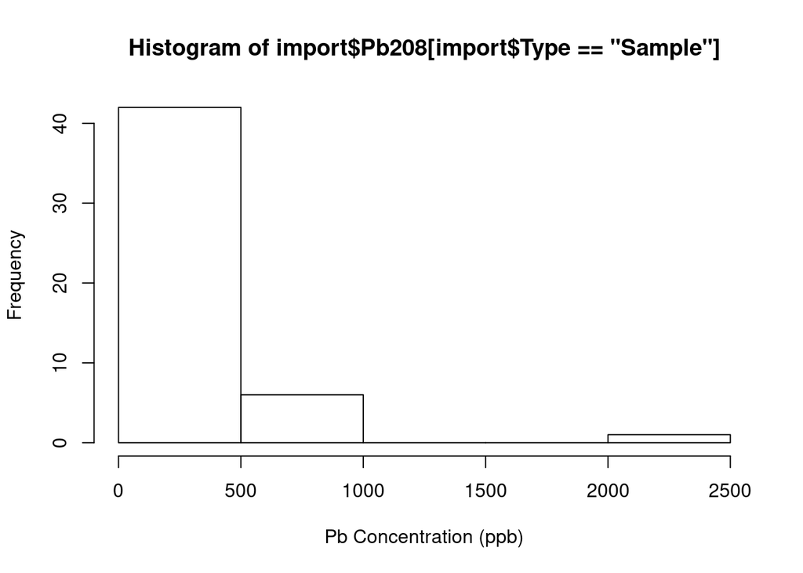

```r
hist(import$Pb208[import$Type=="Sample"], xlab="Pb Concentration (ppb)")
```

Based on this, let’s create a dataset that only has the samples, so we don’t have to worry about this for the rest of the analysis. To do this we can use the subset() function.

```r
parkdata = subset(import, subset=import$Type=="Sample" & import$Sample.Name!="Blank")
```

## Converting the Values on a per gram of soil basis

Currently, we have a concentration based on 10 grams of soil that was digested and diluted upto 100 mL. So, we next need to change our concentration in the digestion relative to the soils (ug/g -> mg/kg)

```r
parkdata$SoilPb = parkdata$Pb208/10
```

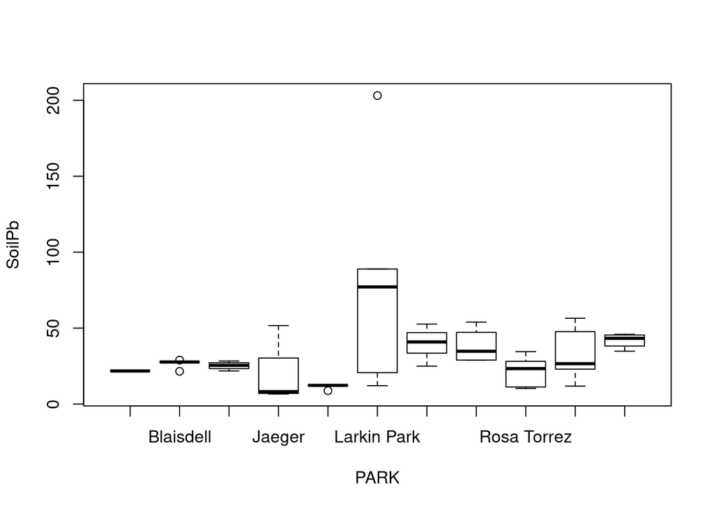

```r
boxplot(SoilPb ~ PARK, data=parkdata)
```

Let’s fix the names of the parks and then adjust the size to fit on the boxplot.

```r
droplevels(parkdata$PARK)
```

```
##  [1] Marston               Marston               Blaisdell
##  [4] Blaisdell             Blaisdell             Blaisdell
##  [7] Jaeger                Marston               Memorial Park
## [10] Marston               Jaeger                Blaisdell
## [13] Jaeger                Jaeger                Memorial Park
## [16] Rosa Torrez           Memorial Park         Wheeler Park
## [19] Marston               Memorial Park         Rosa Torrez
## [22] Wheeler Park          Wheeler Park
## [25] Jaeger                Rosa Torrez           Rosa Torrez
## [28] Rosa Torrez           Wheeler Park          CPark
## [31] <NA>                  La Puerta Sports Park La Puerta Sports Park
## [34] La Puerta Sports Park La Puerta Sports Park La Puerta Sports Park
## [37] CPark                 Larkin Park           Walker Beach
## [40] CPark                 CPark                 Larkin Park
## [43] Walker Beach          Walker Beach          Larkin Park
## [46] Larkin Park           Walker Beach          Larkin Park
## [49] Walker Beach          <NA>
## 11 Levels:  Blaisdell CPark Jaeger La Puerta Sports Park ... Wheeler Park
```

```r
levels(parkdata$PARK) <- c("Unknown", "Blaisdell", "CPark", "Jaeger", "La Puerta", "Larkin", "Marston", "Memorial", "R. Torrez", "Walker", "Wheeler")
```

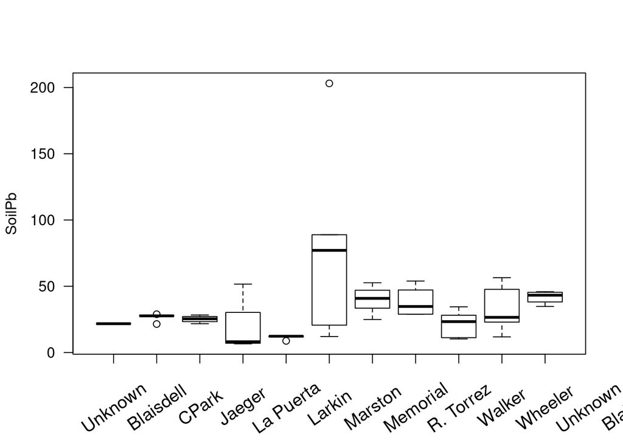

```r
par(las=1)
boxplot(SoilPb ~ PARK, data=parkdata, xlab="", xaxt="n")
axis(1, 1:11, parkdata$PARK, labels=F)

text(x = 1:length(parkdata$PARK),
     y = par("usr")[3] - 40,
     labels = unique(levels(parkdata$PARK)),
     xpd = NA,
     ## Rotate the labels by 35 degrees.
     srt = 35,
     cex = 1.2)
```

## Null Hypothesis Testing

No difference between Pb by parks.

```r
pb.aov <- aov(SoilPb ~ PARK, data=parkdata)
summary(pb.aov)
```

```
##             Df Sum Sq Mean Sq F value Pr(>F)
## PARK        10  16168  1616.8   2.103 0.0503 .
## Residuals   36  27674   768.7
## ---
## Signif. codes:  0 '***' 0.001 '**' 0.01 '*' 0.05 '.' 0.1 ' ' 1
## 3 observations deleted due to missingness
```

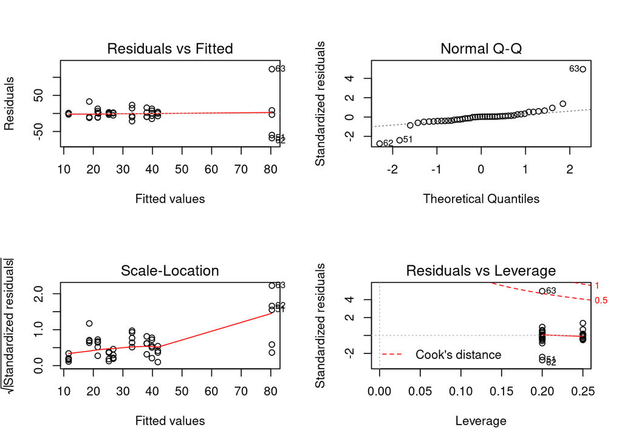

```r
par(mfrow=c(2,2))
plot(pb.aov)
```

```r
par(mfrow=c(1,1))
```

Testing distance

```r
pb.lm <- lm(Pb208 ~ DISTANCE66, data=parkdata)
summary(pb.lm)
```

```
##
## Call:
## lm(formula = Pb208 ~ DISTANCE66, data = parkdata)
##
## Residuals:
##     Min      1Q  Median      3Q     Max
## -311.38 -201.61  -40.20   83.48 1627.94
##
## Coefficients:
##              Estimate Std. Error t value Pr(>|t|)
## (Intercept) 437.36892   95.37638   4.586 4.39e-05 ***
## DISTANCE66   -0.04574    0.04137  -1.106    0.275
## ---
## Signif. codes:  0 '***' 0.001 '**' 0.01 '*' 0.05 '.' 0.1 ' ' 1
##
## Residual standard error: 324.3 on 40 degrees of freedom
##   (8 observations deleted due to missingness)
## Multiple R-squared:  0.02966,    Adjusted R-squared:  0.005405
## F-statistic: 1.223 on 1 and 40 DF,  p-value: 0.2754
```

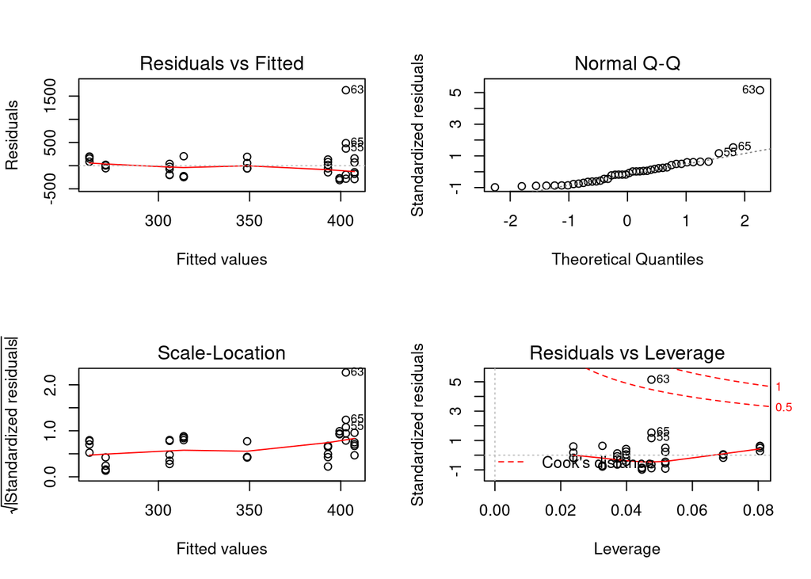

```r
par(mfrow=c(2,2))
plot(pb.lm)
```

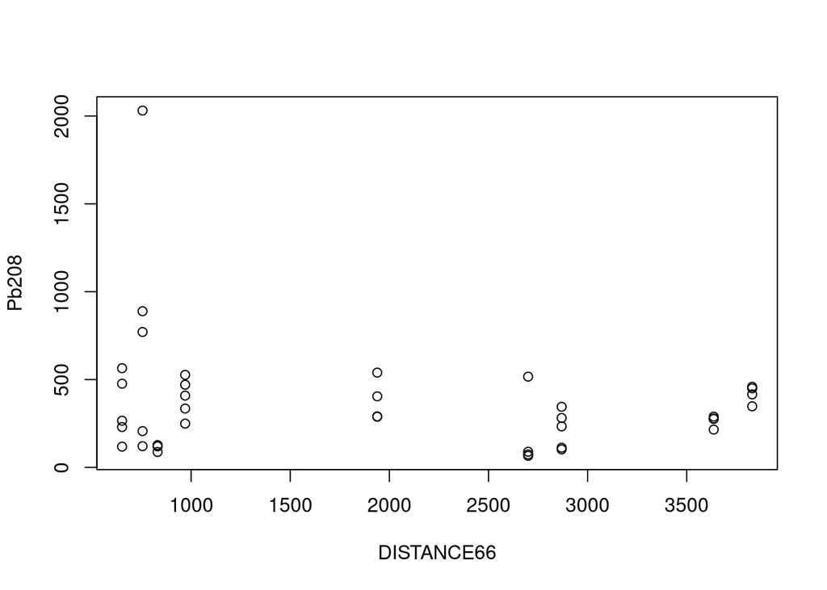

```r
par(mfrow=c(1,1))
plot(Pb208 ~ DISTANCE66, data=parkdata)
```